# Assignment4

By *Changyu Gao*, PB15121717

## 5.20

Import data

```r
X1 <- read.table("T5-12.DAT", col.names = c("tail", "wing"))
head(X1)
```

```
##   tail wing
## 1  191  284
## 2  197  285
## 3  208  288
## 4  180  273
## 5  180  275
## 6  188  280
```

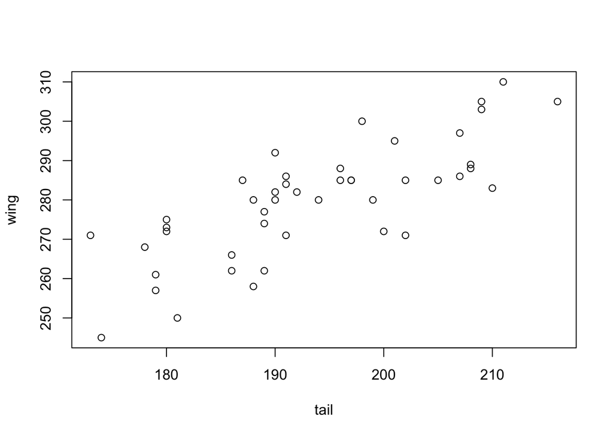

```r
meanX1 <- colMeans(X1)
covX1 <- cov(X1)
p1 <- ncol(X1)
n1 <- nrow(X1)
with(X1, plot(tail, wing))
```

Compute 95% confidence ellipsoid

```r
require(car)
eigensys1 <- eigen(covX1)
eigensys1$vectors # eigenvectors, i.e. axes of the ellipsoid
```

```
##           [,1]       [,2]
## [1,] 0.5753739 -0.8178905
## [2,] 0.8178905  0.5753739
```

```r
alpha = .05

fscale <- function(p, n, a) {
  p*(n-1)/(n-p)/n * qf(1-a, p, n-p)
} # compute scale for ellipsoid

radius1 <- sqrt(fscale(p1, n1, alpha))
axesLength <- sqrt(eigensys1$values) * radius1
axesLength # length of axes
```

```
## [1] 6.562650 2.249882
```

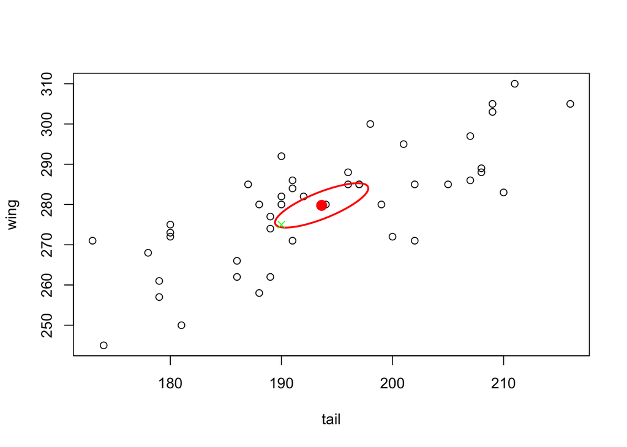

```r
with(X1, plot(tail, wing))
ellipse1 <- ellipse(meanX1, covX1, radius1)
points(190, 275, col="green", pch=4)
```

We can see that point $(190, 275)$ (marked in green in the plot) falls into the 95% confidence ellipse. Therefore, we conclude these are plausible values.

Intervals

```r
cat("T^2 Simultaneous intervals:")
```

```
## T^2 Simultaneous intervals:
```

```r
with(X1, plot(tail, wing))
ellipse1 <- ellipse(meanX1, covX1, radius1)
d1 <- radius1 * sqrt(covX1[1, 1])
d2 <- radius1 * sqrt(covX1[2, 2])
sprintf("mu1: (%f, %f), mu2: (%f, %f)",
        meanX1[1] - d1, meanX1[1] + d1,
        meanX1[2] - d2, meanX1[2] + d2)
```

```
## [1] "mu1: (189.421724, 197.822720), mu2: (274.256351, 285.299205)"
```

```r
rect(meanX1[1] - d1, meanX1[2] - d2, meanX1[1] + d1, meanX1[2] + d2, lty = 1)
cat("Bonferroni intervals:")
```

```
## Bonferroni intervals:
```

```r
tcoef <- qt(1 - alpha / (2*p1), n1 - 1)
d1 <- tcoef * sqrt(covX1[1, 1] / n1)
d2 <- tcoef * sqrt(covX1[2, 2] / n1)
sprintf("mu1: (%f, %f), mu2: (%f, %f)",
        meanX1[1] - d1, meanX1[1] + d1,
        meanX1[2] - d2, meanX1[2] + d2)
```

```
## [1] "mu1: (189.821560, 197.422885), mu2: (274.781922, 284.773633)"
```

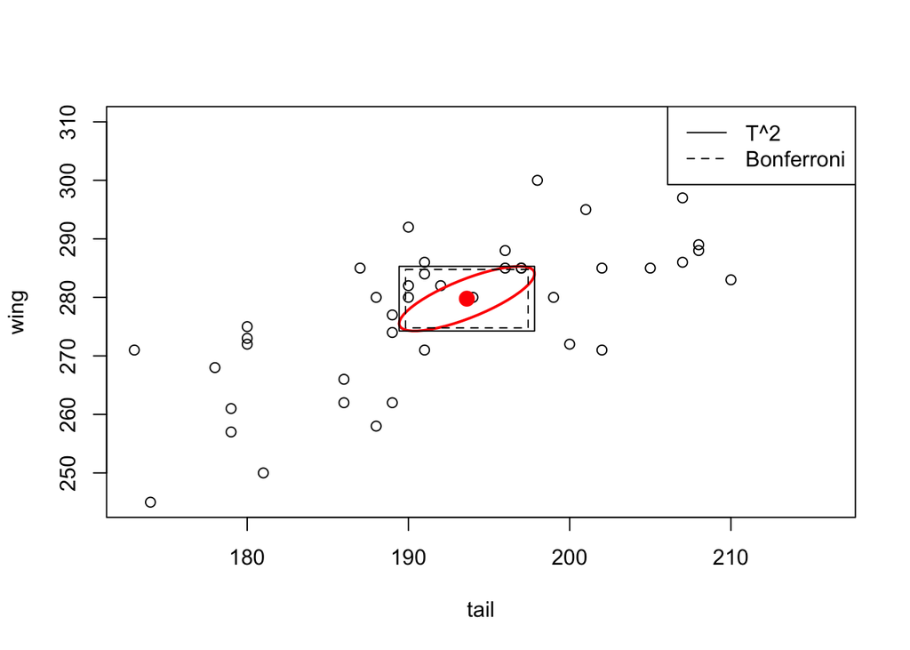

```r
rect(meanX1[1] - d1, meanX1[2] - d2, meanX1[1] + d1, meanX1[2] + d2, lty = 2)
legend("topright", legend = c("T^2", "Bonferroni"), lty = c(1, 2))
```

Although $T^2$ simultaneous intervals are longer than those of Bonferroni’s, $T^2$ intervals are effective for all combinations of $\mu_i$’s while Bonferroni’s are only valid for those specified ones.

Q-Q Plot

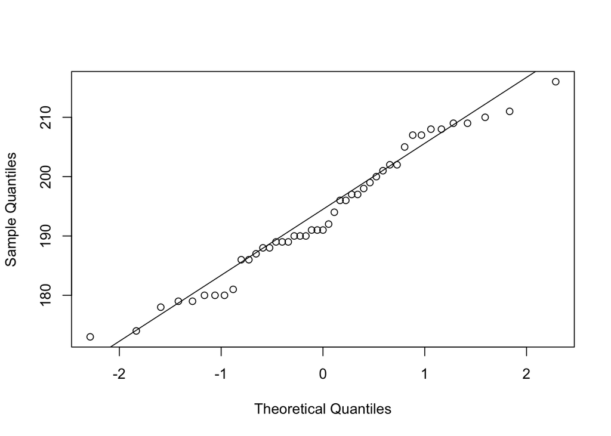

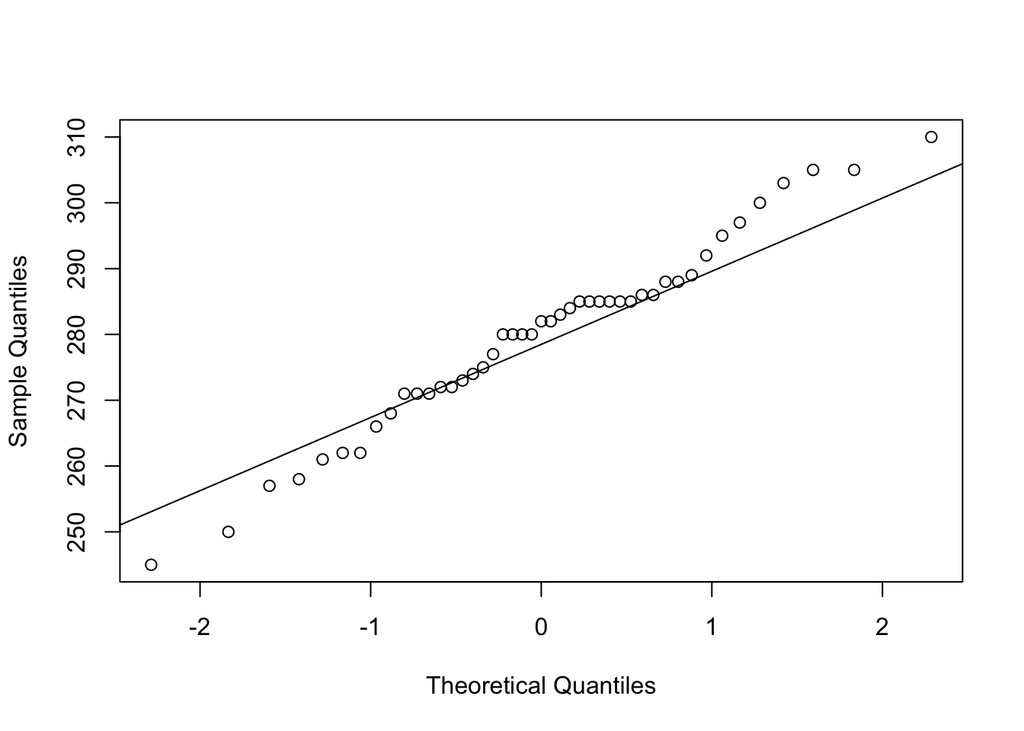

```r
plotqq <- function(col, title="") {
  qqp <- qqnorm(col, main = title)
  qqline(col)
  with(qqp, cor(x, y))
}
rqs1 <- sapply(X1, plotqq)
```

```r
rqs1
```

```
##      tail      wing
## 0.9873854 0.9912863
```

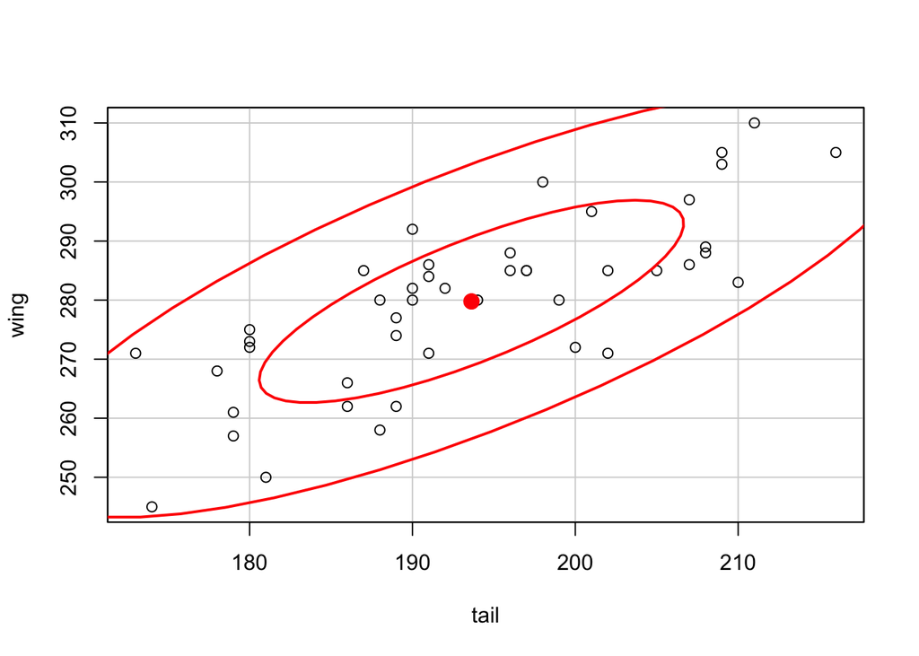

```r
with(X1, dataEllipse(tail, wing))
```

We observe that Q-Q plots for tail and wing are both approximately straight lines and the correlation coefficients are > 0.985. Furthermore, the scatter plot has approximately elliptical shape. We conclude that the bivariate normal distribution is a viable population model.

## 5.22

Import data

```r
X2 <- read.table("T5-13.dat", col.names = c("fuel", "repair", "capital"))
head(X2)
```

```
##    fuel repair capital
## 1 16.44  12.43   11.23
## 2  7.19   2.70    3.92
## 3  9.92   1.35    9.75
## 4  4.24   5.78    7.78
## 5 11.20   5.05   10.67
## 6 14.25   5.78    9.88
```

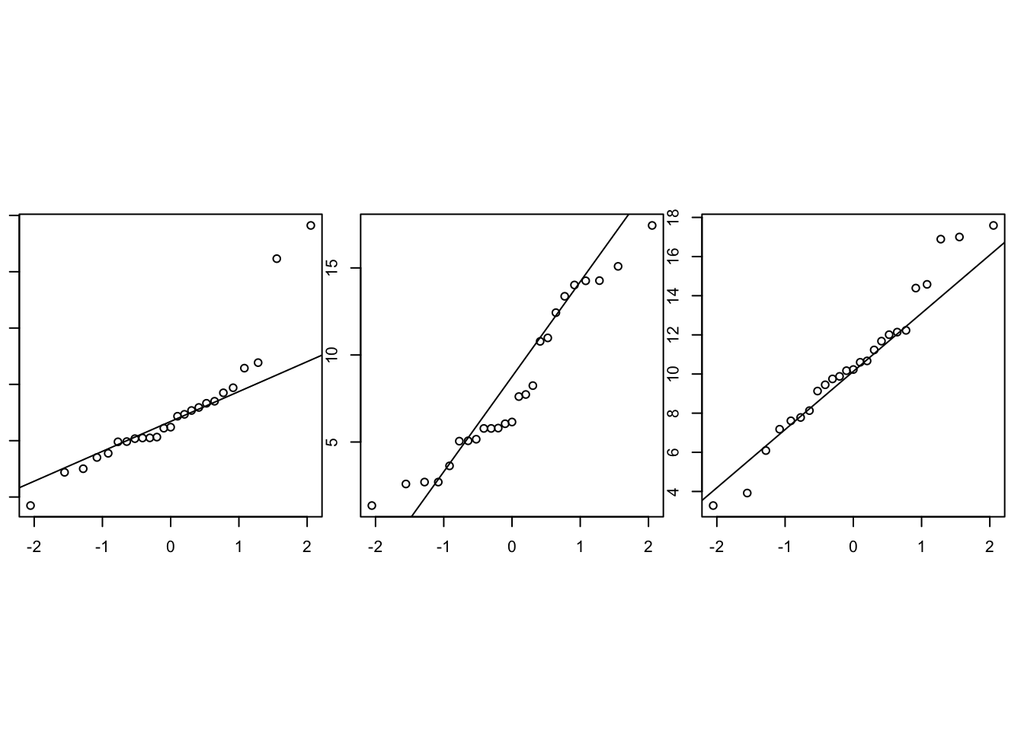

```r
layout(matrix(1:3, nrow = 1, byrow = TRUE), respect = TRUE)
par(mar = rep.int(1, 4))
rqs2 <- sapply(X2, plotqq)
```

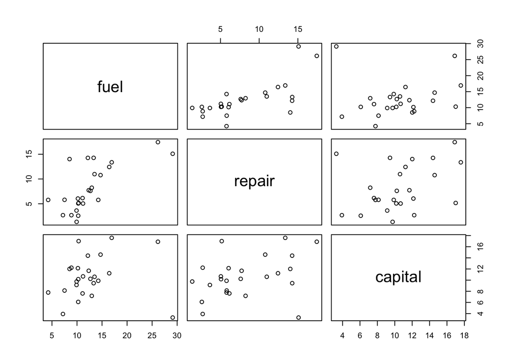

```r
pairs(X2)
```

We can clealy find out two outliers. Now we will remove them.

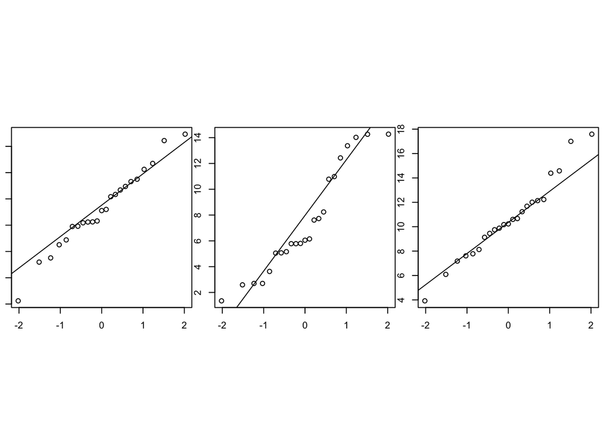

```r
X2_ <- X2[c(-9, -21), ]
layout(matrix(1:3, nrow = 1, byrow = TRUE), respect = TRUE)
par(mar = rep.int(1, 4))
rqs2_ <- sapply(X2_, plotqq)
```

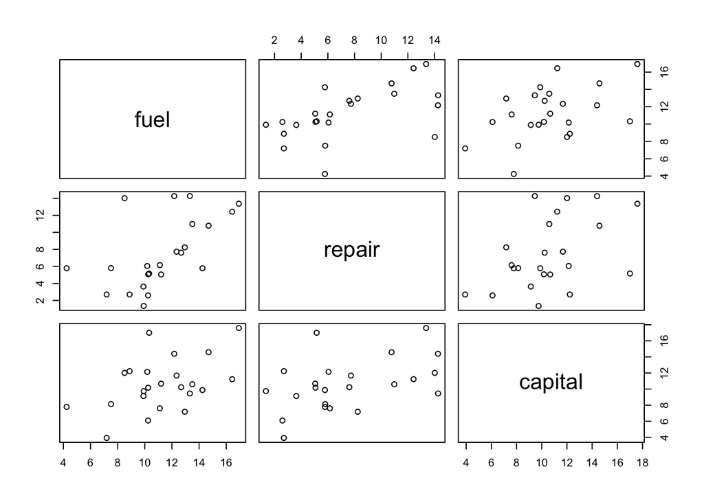

```r
pairs(X2_)
```

After removing the outliers, we construct the Q-Q plots. The data now appear to be normally distributed as Q-Q plots are nearly straight lines. Also, we look up the table with size $n=25$, significant level $\alpha=.05$ and find that the critical value is .9591 which is less than each of the correlation coefficients of 3 variables. Therefore we have confidence of the marginal normality at level of significance $\alpha=.05$

```r
meanX2 <- colMeans(X2)
covX2 <- cov(X2)
p2 <- ncol(X2)
n2 <- nrow(X2)

radius2 <- sqrt(fscale(p2, n2, alpha))
d1 <- radius2 * sqrt(covX2[1, 1])
d2 <- radius2 * sqrt(covX2[2, 2])
d3 <- radius2 * sqrt(covX2[3, 3])
cat(sprintf("T^2 Simultaneous intervals:\nmu1: (%f, %f), mu2: (%f, %f), mu3: (%f, %f)",
        meanX2[1] - d1, meanX2[1] + d1,
        meanX2[2] - d2, meanX2[2] + d2,
        meanX2[2] - d3, meanX2[2] + d3))
```

```
## T^2 Simultaneous intervals:
## mu1: (9.159708, 15.960292), mu2: (5.234926, 11.087474), mu3: (5.831357, 10.491043)
```

```r
tcoef <- qt(1 - alpha / (2*p2), n2 - 1)
d1 <- tcoef * sqrt(covX2[1, 1] / n2)
d2 <- tcoef * sqrt(covX2[2, 2] / n2)
d3 <- tcoef * sqrt(covX2[3, 3] / n2)
cat(sprintf("Bonferroni intervals:\nmu1: (%f, %f), mu2: (%f, %f), mu3: (%f, %f)",
        meanX2[1] - d1, meanX2[1] + d1,
        meanX2[2] - d2, meanX2[2] + d2,
        meanX2[2] - d3, meanX2[2] + d3))
```

```
## Bonferroni intervals:
## mu1: (9.789733, 15.330267), mu2: (5.777122, 10.545278), mu3: (6.263043, 10.059357)
```

We can see that Bonferroni intervals are shorter than $T^2$ intervals. However, $T^2$ intervals are effective for all combinations of $\mu_i$’s while Bonferroni’s are not.

## 5.23

Import data

```r
X3 <- read.table("T6-13.DAT")
X3 <- X3[X3$V5 == 1, -5] # select rows of which period is 1
head(X3)
```

```
##    V1  V2  V3 V4
## 1 131 138  89 49
## 2 125 131  92 48
## 3 131 132  99 50
## 4 119 132  96 44
## 5 136 143 100 54
## 6 138 137  89 56
```

Construct Q-Q plots

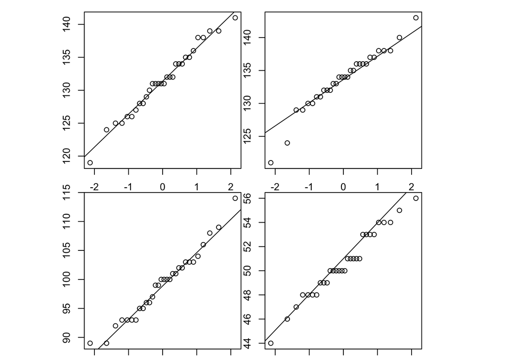

```r
meanX3 <- colMeans(X3)
covX3 <- cov(X3)
p3 <- ncol(X3)
n3 <- nrow(X3)

layout(matrix(1:4, nrow = 2, byrow = TRUE), respect = TRUE)
par(mar = rep.int(1, 4))
rqs3 <- sapply(X3, plotqq)
```

```r
rqs3
```

```
##        V1        V2        V3        V4
## 0.9910099 0.9743185 0.9868455 0.9871853
```

```r
# Chi-square
dev.off() # clean plots
```

```r
squaredDist <- mahalanobis(X3, meanX3, covX3)
qqplot(qchisq(ppoints(n3, a = .5), df = p3), squaredDist, main = "Chi-square Q-Q Plot", xlab = "Theoretical Quantiles", ylab = "Sample Quantiles")
sum(squaredDist <= qchisq(.5, df = p3)) / n3 # % of falling into first half
```

[output not shown]

```
## [1] 0.5333333
```

These Q-Q plots are approximately straight lines. Also, we look up the table with size $n=30$, significant level $\alpha=.10$ and find that the critical value is .9715 which is less than each of the correlation coefficients of 4 variables. Therefore we have confidence of the marginal normality at level of significance $\alpha=.10$

```r
radius3 <- sqrt(fscale(p3, n3, alpha))
d1 <- radius2 * sqrt(covX3[1, 1])
d2 <- radius2 * sqrt(covX3[2, 2])
d3 <- radius2 * sqrt(covX3[3, 3])
cat(sprintf("T^2 Simultaneous intervals:\nmu1: (%f, %f), mu2: (%f, %f), mu3: (%f, %f)",
        meanX3[1] - d1, meanX3[1] + d1,
        meanX3[2] - d2, meanX3[2] + d2,
        meanX3[2] - d3, meanX3[2] + d3))
```

```
## T^2 Simultaneous intervals:
## mu1: (128.126060, 134.607273), mu2: (130.776500, 136.423500), mu3: (129.882282, 137.317718)
```

```r
tcoef <- qt(1 - alpha / (2*p2), n2 - 1)
d1 <- tcoef * sqrt(covX3[1, 1] / n2)
d2 <- tcoef * sqrt(covX3[2, 2] / n2)
d3 <- tcoef * sqrt(covX3[3, 3] / n2)
cat(sprintf("Bonferroni intervals:\nmu1: (%f, %f), mu2: (%f, %f), mu3: (%f, %f)",
        meanX3[1] - d1, meanX3[1] + d1,
        meanX3[2] - d2, meanX3[2] + d2,
        meanX3[2] - d3, meanX3[2] + d3))
```

```
## Bonferroni intervals:
## mu1: (128.726498, 134.006836), mu2: (131.299654, 135.900346), mu3: (130.571121, 136.628879)
```

We can see that Bonferroni intervals are shorter than $T^2$ intervals. However, $T^2$ intervals are effective for all combinations of $\mu_i$’s while Bonferroni’s are not. ```